# Eksplorasi dan Identifikasi Lag

# Packages

```r
library(ggplot2)
library(tsibble)
library(tseries)
library(MASS)
library(forecast)
library(TSA)
library(TTR)
library(aTSA)
library(graphics)
library(readxl)
library(vars)
library(urca)
library(zoo)
library(lmtest)
```

# Data

```r
dt <- read_xlsx("D:\\KULIAHH\\SEMESTER 7\\TA\\Data\\Data Skripsi.xlsx")
dk.ts<-ts(dt$Kurs)
di.ts<-ts(dt$Inflasi)
dw.ts<-ts(dt$Wisatawan)
```

# Nilai Tukar Rupiah

## Eksplorasi Data

### Plot Data

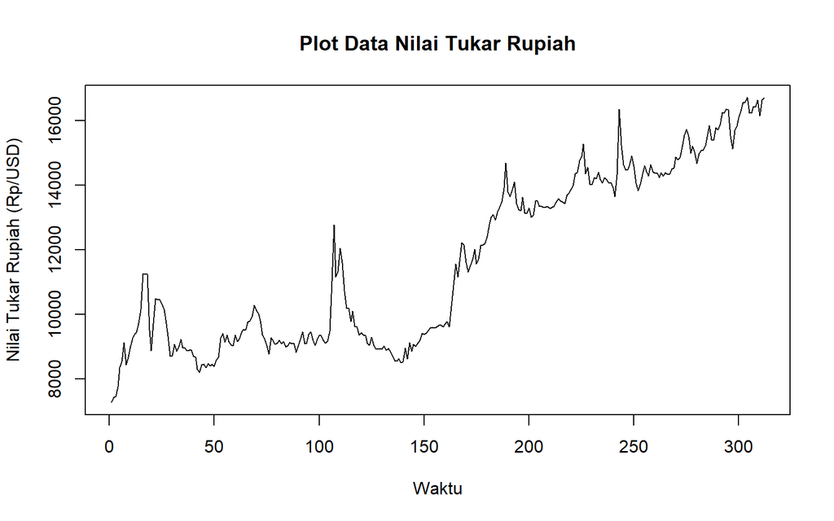

```r
plot.ts(dk.ts, lty=1, xlab="Waktu", ylab="Nilai Tukar Rupiah (Rp/USD)", main="Plot Data Nilai Tukar Rupiah")
```

Berdasarkan plot data deret waktu, terlihat bahwa data cenderung memiliki trend fluktuatif dari naik ke turun dan kembali naik.

## Uji Stasioneritas Data

### Plot ACF

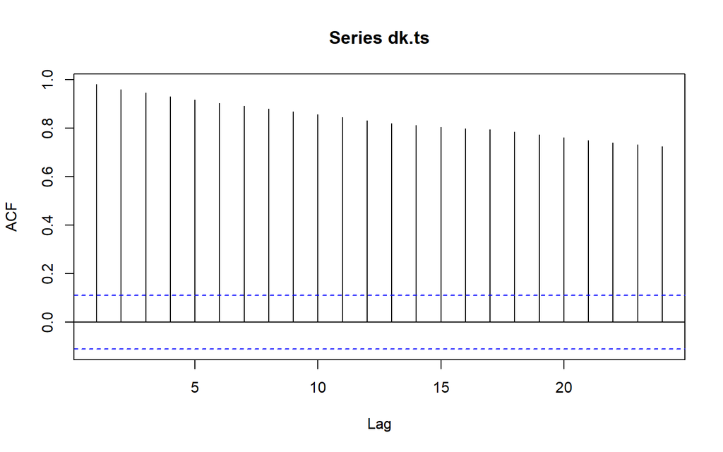

```r
acf(dk.ts)
```

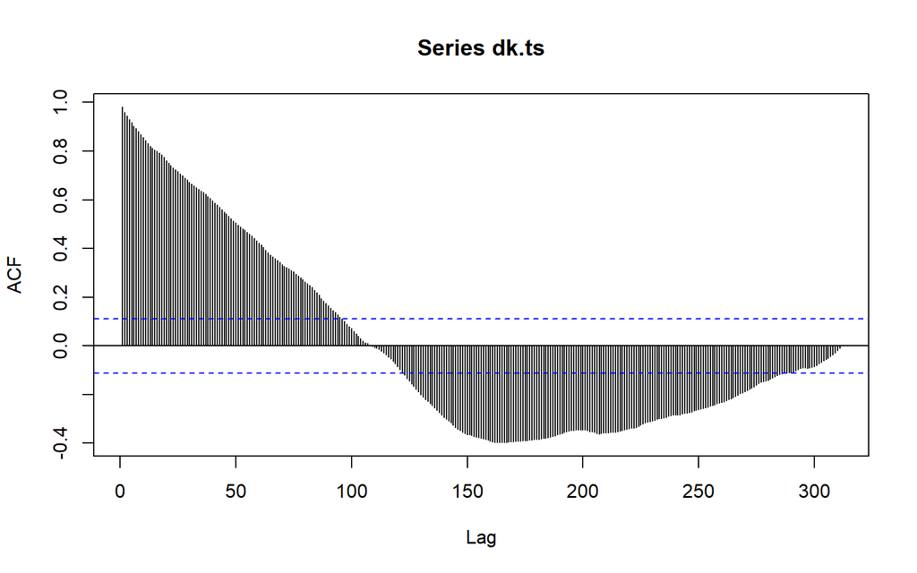

```r
acf(dk.ts, lag.max = length(dk.ts) - 1)
```

Berdasarkan plot ACF, terlihat bahwa plot ACF data menurun secara perlahan (*tails of slowly*). Hal ini juga menjadi indikasi bahwa data tidak stasioner dalam rataan

### Uji ADF

```r
tseries::adf.test(dk.ts)
```

```
##
##  Augmented Dickey-Fuller Test
##
## data:  dk.ts
## Dickey-Fuller = -2.3711, Lag order = 6, p-value = 0.42
## alternative hypothesis: stationary
```

Berdasarkan uji ADF tersebut, didapat *p-value* sebesar 0.42 yang lebih besar dari taraf nyata 5% sehingga tak tolak $H_0$ dan menandakan bahwa data tidak stasioner dalam rataan. Hal ini sesuai dengan hasil eksplorasi menggunakan plot time series dan plot ACF, sehingga ketidakstasioneran model kedepannya harus ditangani

### Plot Box-Cox

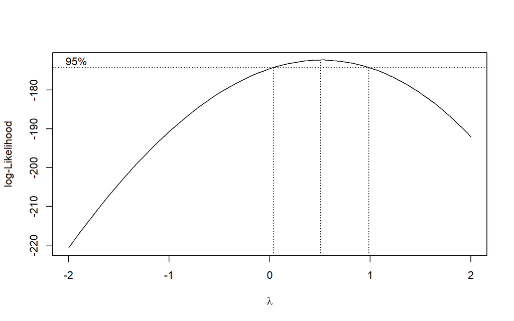

```r
index <- seq(1:312)
bc = boxcox(dk.ts~index, lambda = seq(-2,2,by=1))
```

```r
#Nilai Rounded Lambda
lambdak <- bc$x[which.max(bc$y)]
lambdak
```

```
## [1] 0.5050505
```

```r
#SK
bc$x[bc$y > max(bc$y) - 1/2 * qchisq(.95,1)]
```

```
##  [1] 0.06060606 0.10101010 0.14141414 0.18181818 0.22222222 0.26262626
##  [7] 0.30303030 0.34343434 0.38383838 0.42424242 0.46464646 0.50505051
## [13] 0.54545455 0.58585859 0.62626263 0.66666667 0.70707071 0.74747475
## [19] 0.78787879 0.82828283 0.86868687 0.90909091 0.94949495
```

Plot Boxcox menunjukkan nilai *rounded value* ($\lambda$) optimum sebesar **0,5050** dan pada selang kepercayaan 95% nilai memiliki batas bawah **0.0606** dan batas atas **0.9495**. Selang tersebut tidak memuat nilai satu sehingga data tidak stasioner dalam ragam.

## Penanganan Ketidakstasioneran Data

### Transformasi Box-Cox

```r
dk.ts <- (dk.ts^lambdak - 1) / lambdak
```

### Plot Box-Cox

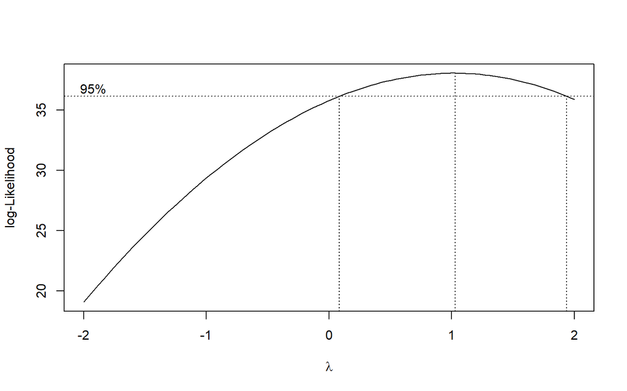

```r
index <- seq_along(dk.ts)

bc = boxcox(dk.ts~index, lambda = seq(-2,2,by=1))
```

```r
#Nilai Rounded Lambda
lambdak <- bc$x[which.max(bc$y)]
lambdak
```

```
## [1] 1.030303
```

```r
#SK
bc$x[bc$y > max(bc$y) - 1/2 * qchisq(.95,1)]
```

```
##  [1] 0.1010101 0.1414141 0.1818182 0.2222222 0.2626263 0.3030303 0.3434343
##  [8] 0.3838384 0.4242424 0.4646465 0.5050505 0.5454545 0.5858586 0.6262626
## [15] 0.6666667 0.7070707 0.7474747 0.7878788 0.8282828 0.8686869 0.9090909
## [22] 0.9494949 0.9898990 1.0303030 1.0707071 1.1111111 1.1515152 1.1919192
## [29] 1.2323232 1.2727273 1.3131313 1.3535354 1.3939394 1.4343434 1.4747475
## [36] 1.5151515 1.5555556 1.5959596 1.6363636 1.6767677 1.7171717 1.7575758
## [43] 1.7979798 1.8383838 1.8787879 1.9191919
```

### Differencing

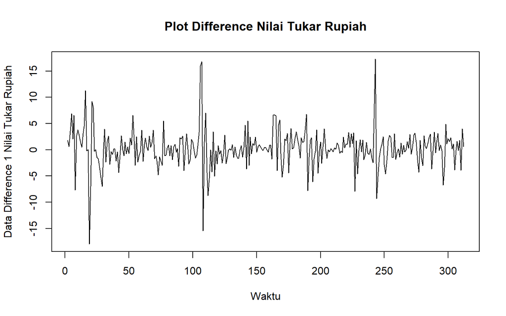

```r
dk.diff <- diff(dk.ts,differences = 1)
plot.ts(dk.diff, lty=1, xlab="Waktu", ylab="Data Difference 1 Nilai Tukar Rupiah", main="Plot Difference Nilai Tukar Rupiah")
```

Berdasarkan plot data deret waktu, terlihat bahwa data sudah stasioner dalam rataan ditandai dengan data bergerak pada nilai tengah tertentu

### Plot ACF

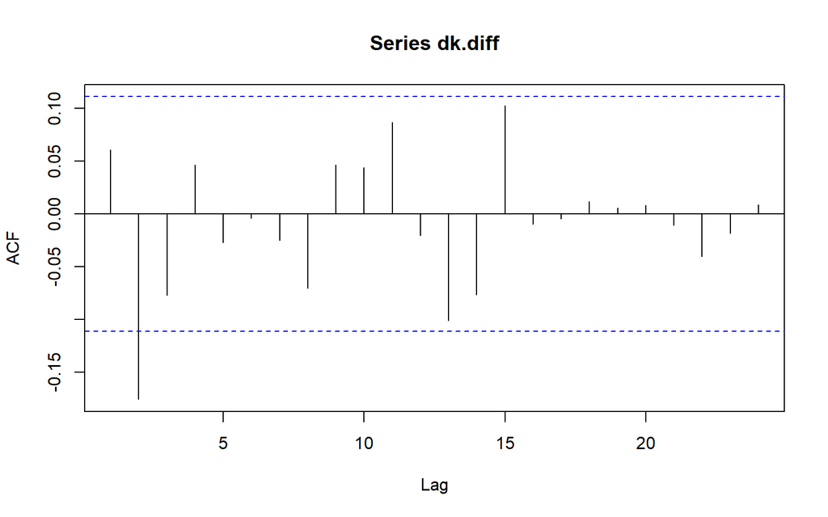

```r
acf(dk.diff)
```

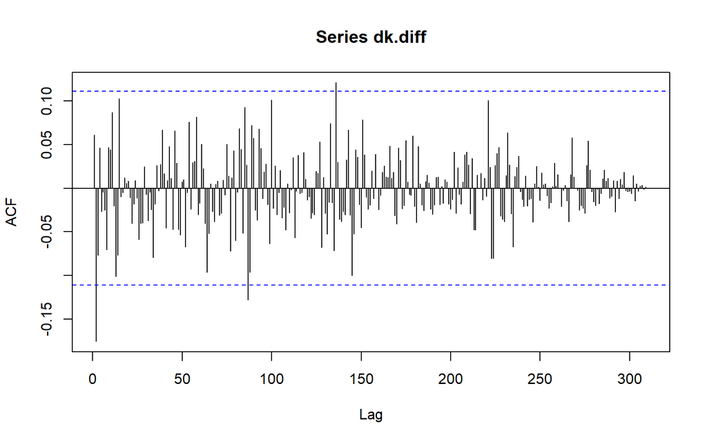

```r
acf(dk.diff, lag.max = length(dk.diff) - 1)
```

Berdasarkan plot tersebut, terlihat bahwa plot ACF tidak tails off slowly. Hal ini menandakan data sudah stasioner dalam rataan dan ketidakstasioneran data telah berhasil tertangani.

### Uji ADF

```r
tseries::adf.test(dk.diff)
```

```
##
##  Augmented Dickey-Fuller Test
##
## data:  dk.diff
## Dickey-Fuller = -7.341, Lag order = 6, p-value = 0.01
## alternative hypothesis: stationary
```

Berdasarkan uji ADF tersebut, didapat *p-value* sebesar 0.01 yang lebih kecil dari taraf nyata 5% sehingga tolak $H_0$ atau data stasioner dalam rataan. Hal ini sesuai dengan hasil eksplorasi menggunakan plot time series dan plot ACF, sehingga dalam hal ini ketidakstasioneran data sudah berhasil ditangani dan dapat dilanjutkan ke pemodelan

## Identifikasi Lag

### Plot ACF

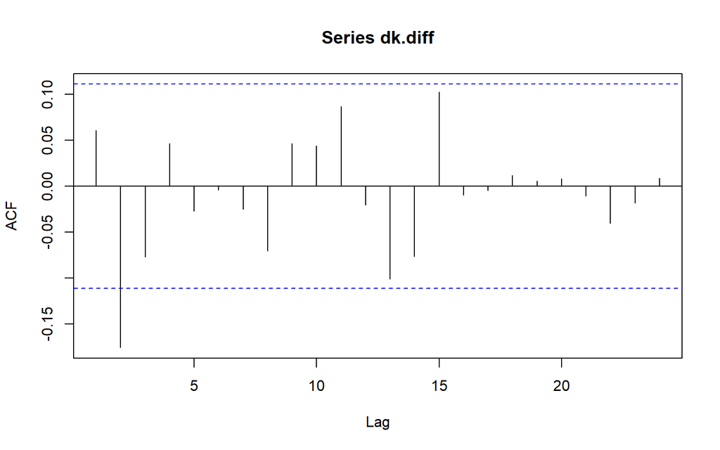

```r
acf(dk.diff)
```

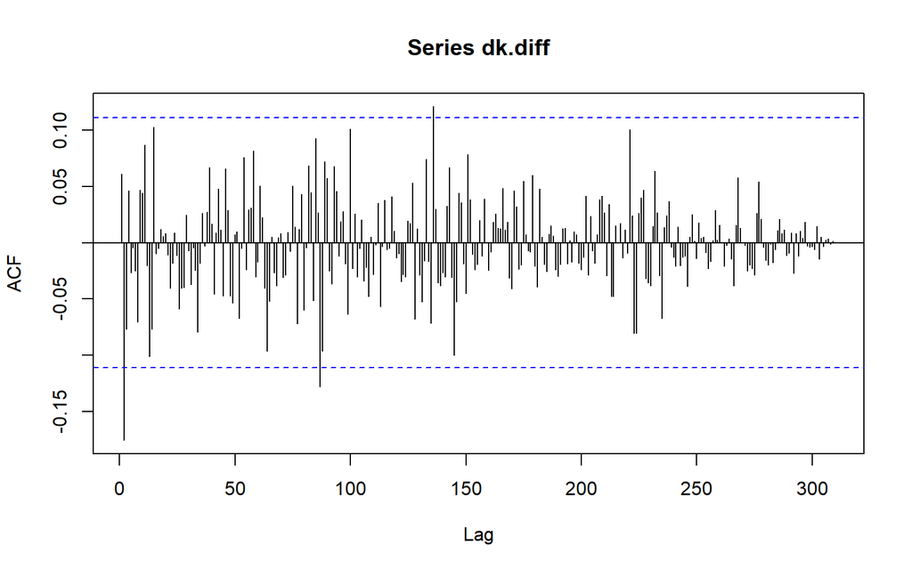

```r
acf(dk.diff, lag.max = length(dk.diff) - 1)
```

Berdasarkan plot tersebut, terlihat bahwa plot ACF cut off di lag ke-2.

### Plot PACF

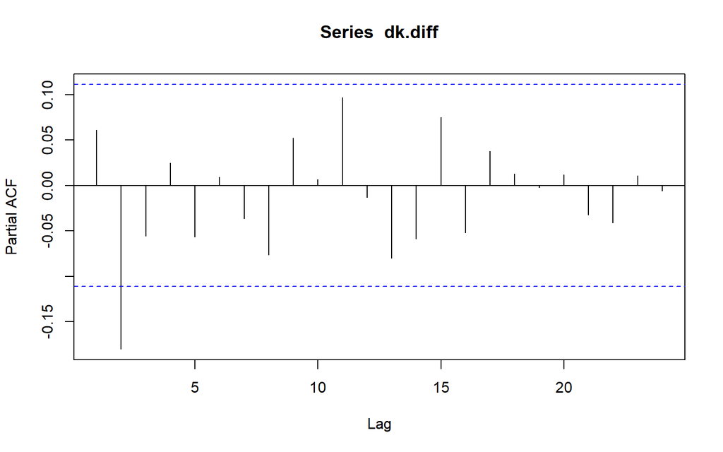

```r
pacf(dk.diff)
```

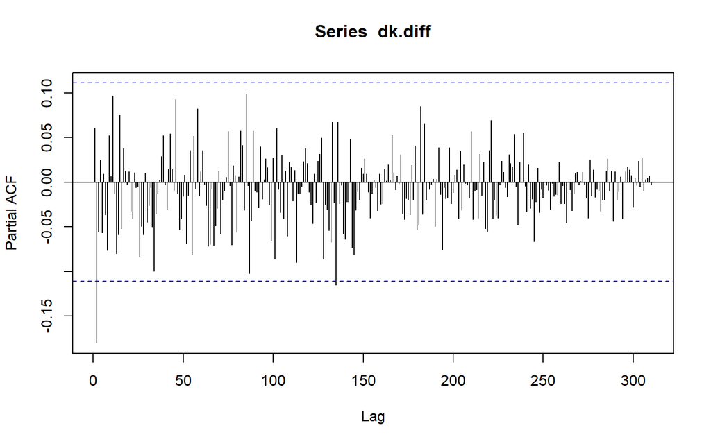

```r
pacf(dk.diff, lag.max = length(dk.diff) - 1)
```

Berdasarkan plot tersebut, terlihat bahwa plot PACF cut off di lag ke-2

# Inflasi

## Eksplorasi Data

### Plot Data

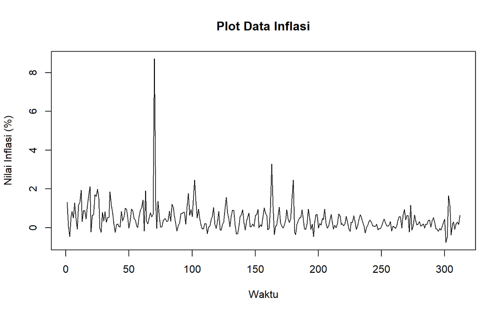

```r
plot.ts(di.ts, lty=1, xlab="Waktu", ylab="Nilai Inflasi (%)", main="Plot Data Inflasi")
```

Berdasarkan plot data deret waktu, terlihat bahwa data cenderung memiliki trend fluktuatif dari turun ke naik dan kembali turun.

## Uji Stasioneritas Data

### Plot ACF

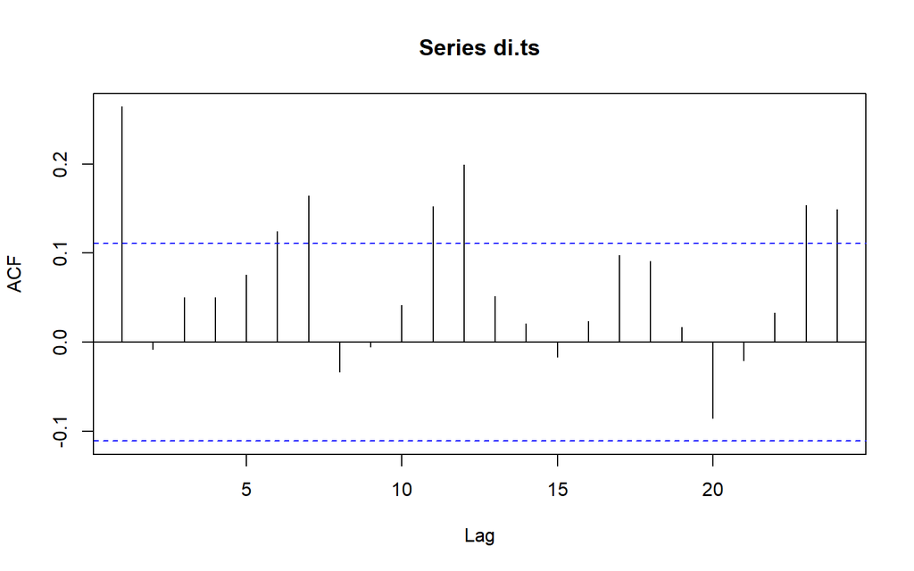

```r
acf(di.ts)
```

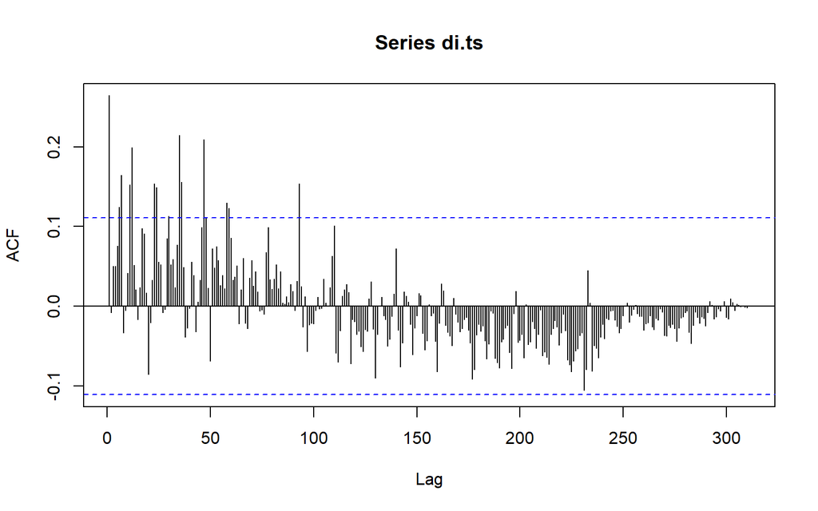

```r
acf(di.ts, lag.max = length(di.ts) - 1)
```

Berdasarkan plot ACF, terlihat bahwa plot ACF data tidak menurun secara perlahan (tidak *tails of slowly*). Hal ini juga menjadi indikasi bahwa data stasioner dalam rataan

### Uji ADF

```r
tseries::adf.test(di.ts)
```

```
##
##  Augmented Dickey-Fuller Test
##
## data:  di.ts
## Dickey-Fuller = -6.0219, Lag order = 6, p-value = 0.01
## alternative hypothesis: stationary
```

Berdasarkan uji ADF tersebut, didapat *p-value* sebesar 0.01 yang lebih kecil dari taraf nyata 5% sehingga tolak $H_0$ dan menandakan bahwa data stasioner dalam rataan.

### Plot Box-Cox

```r
c <- abs(min(di.ts)) + 0.01
di.shift <- di.ts + c
```

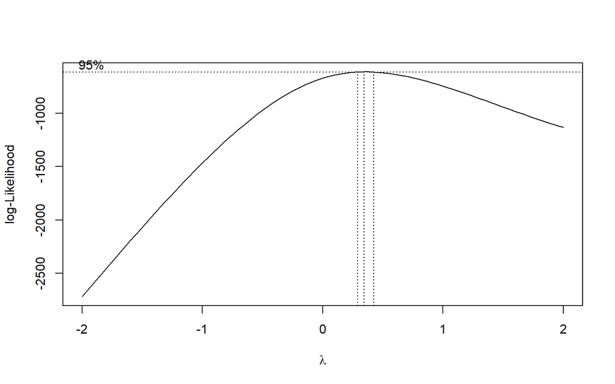

```r
index <- seq(1:312)
bc = boxcox(di.shift~index, lambda = seq(-2,2,by=1))
```

```r
#Nilai Rounded Lambda
lambdai <- bc$x[which.max(bc$y)]
lambdai
```

```
## [1] 0.3434343
```

```r
#SK
bc$x[bc$y > max(bc$y) - 1/2 * qchisq(.95,1)]
```

```
## [1] 0.3030303 0.3434343 0.3838384
```

Plot Boxcox menunjukkan nilai *rounded value* ($\lambda$) optimum sebesar **0.3434** dan pada selang kepercayaan 95% nilai memiliki batas bawah **0.3030** dan batas atas **0.3838**. Selang tersebut tidak memuat nilai satu sehingga data tidak stasioner dalam ragam.

## Penanganan Ketidakstasioneran Data

### Transformasi Box-Cox

```r
di.shift <- (di.shift^lambdai - 1) / lambdai
```

### Plot Box-Cox

```r
c <- abs(min(di.shift)) + 0.01
di.shift2 <- di.shift + c
```

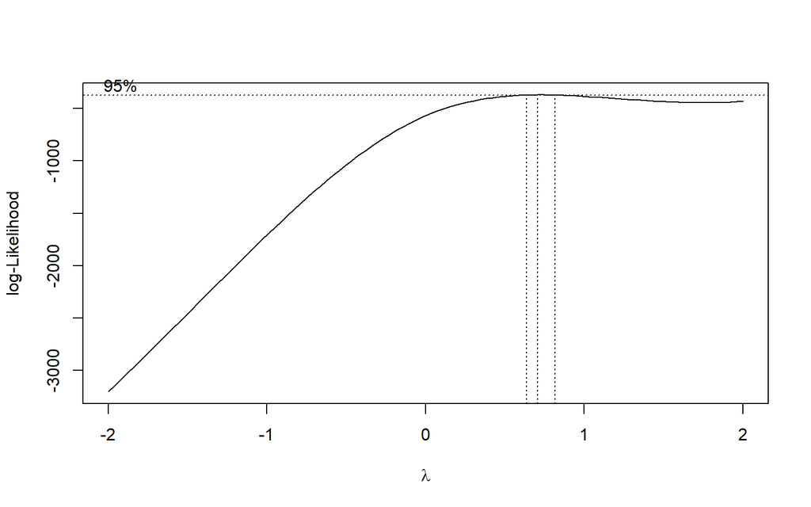

```r
index <- seq_along(di.shift2)
bc = boxcox(di.shift2~index, lambda = seq(-2,2,by=1))
```

```r
#Nilai Rounded Lambda
lambdai <- bc$x[which.max(bc$y)]
lambdai
```

```
## [1] 0.7070707
```

```r
#SK
bc$x[bc$y > max(bc$y) - 1/2 * qchisq(.95,1)]
```

```
## [1] 0.6666667 0.7070707 0.7474747 0.7878788
```

## Penanganan Ketidakstasioneran Data 2

### Transformasi Box-Cox

```r
di.shift2 <- (di.shift2^lambdai - 1) / lambdai
```

### Plot Box-Cox

```r
c <- abs(min(di.shift2)) + 0.01
di.shift3 <- di.shift2 + c
```

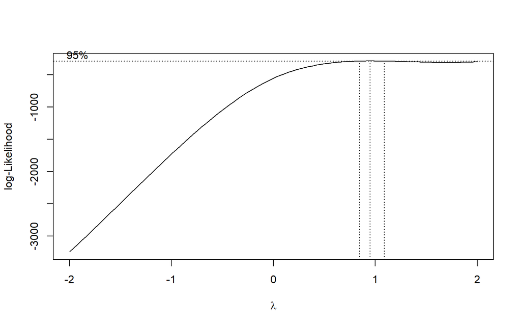

```r
index <- seq_along(di.shift3)
bc = boxcox(di.shift3~index, lambda = seq(-2,2,by=1))
```

```r
#Nilai Rounded Lambda
lambdai <- bc$x[which.max(bc$y)]
lambdai
```

```
## [1] 0.9494949
```

```r
#SK
bc$x[bc$y > max(bc$y) - 1/2 * qchisq(.95,1)]
```

```
## [1] 0.8686869 0.9090909 0.9494949 0.9898990 1.0303030 1.0707071
```

## Identifikasi Lag

### Plot ACF

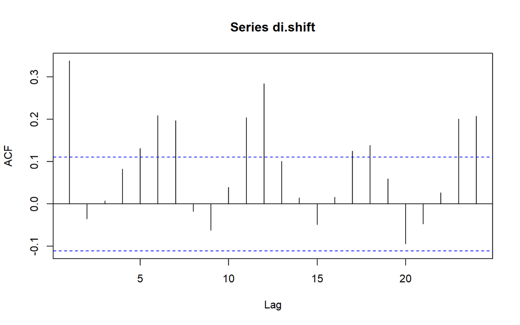

```r
acf(di.shift)
```

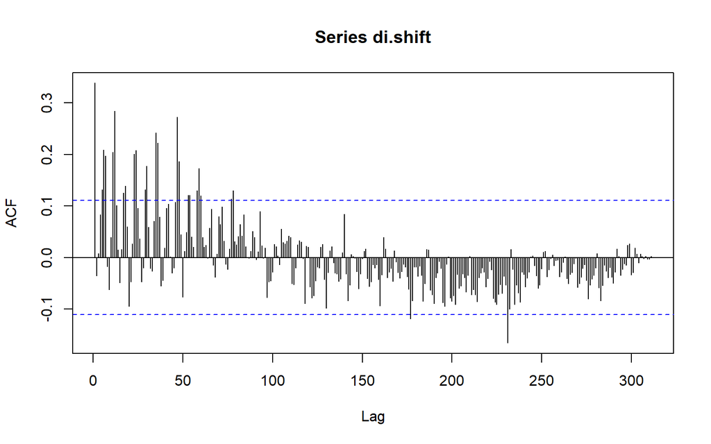

```r
acf(di.shift, lag.max = length(di.shift) - 1)
```

### Plot PACF

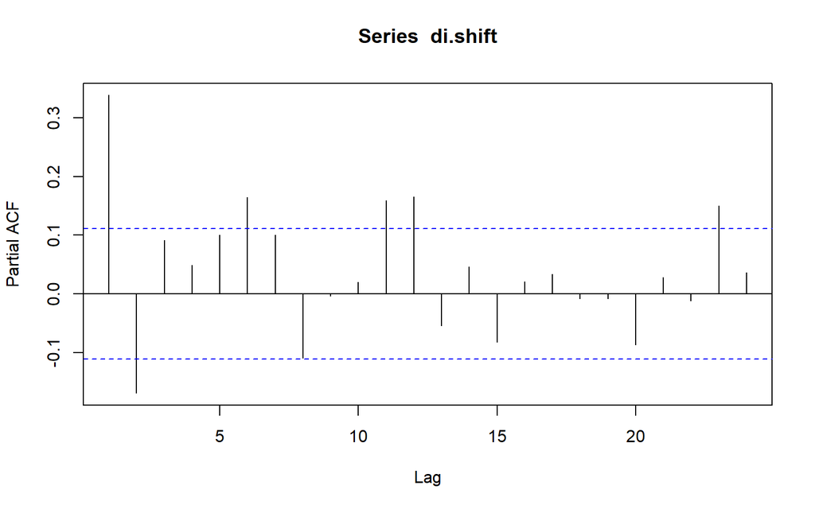

```r
pacf(di.shift)
```

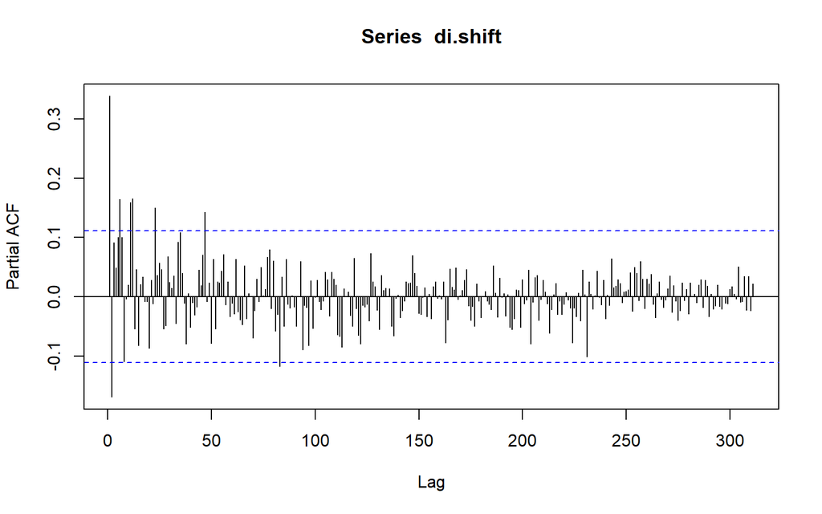

```r
pacf(di.shift, lag.max = length(di.shift) - 1)
```

### Efek Musiman

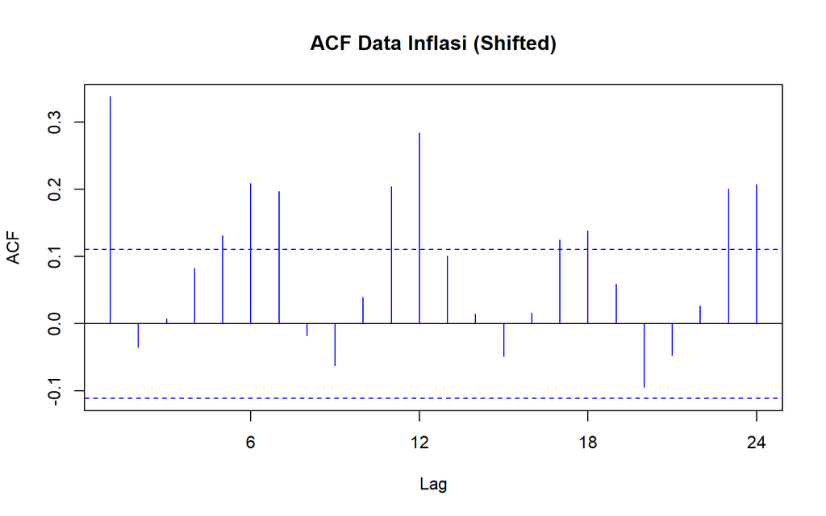

```r
acf0 <- acf(di.shift, main = "ACF Data Inflasi (Shifted)", lag.max = 24, xaxt = "n", col = "blue")
axis(1, at = seq(0, 24, by = 6), labels = seq(0, 24, by = 6))
```

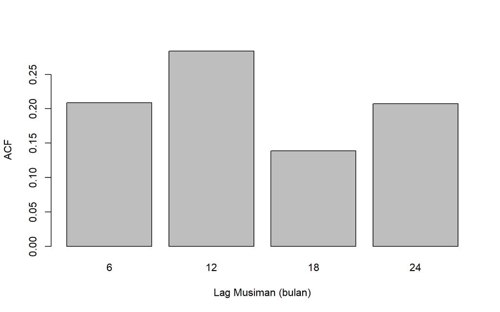

```r
acf_df <- data.frame(acf = as.numeric(acf0$acf), lag = as.numeric(acf0$lag))
acf_seasonal <- acf_df[acf_df$lag %% 6 == 0 & acf_df$lag != 0, ]
barplot(height = acf_seasonal$acf, names.arg = acf_seasonal$lag, ylab = "ACF", xlab = "Lag Musiman (bulan)")
```

Berdasarkan pola tersebut terdapat pola musiman dalam lag ke 6, 12, 18, dan 24 pada data Inflasi.

# Wisatawan

## Eksplorasi Data

### Plot Data

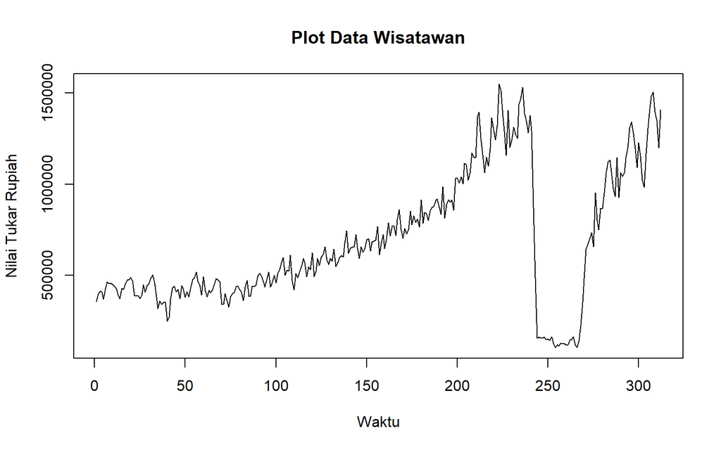

```r
plot.ts(dw.ts, lty=1, xlab="Waktu", ylab="Nilai Tukar Rupiah", main="Plot Data Wisatawan")
```

Berdasarkan plot data deret waktu, terlihat bahwa data cenderung memiliki trend fluktuatif dari naik ke turun dan kembali naik.

## Uji Stasioneritas Data

### Plot ACF

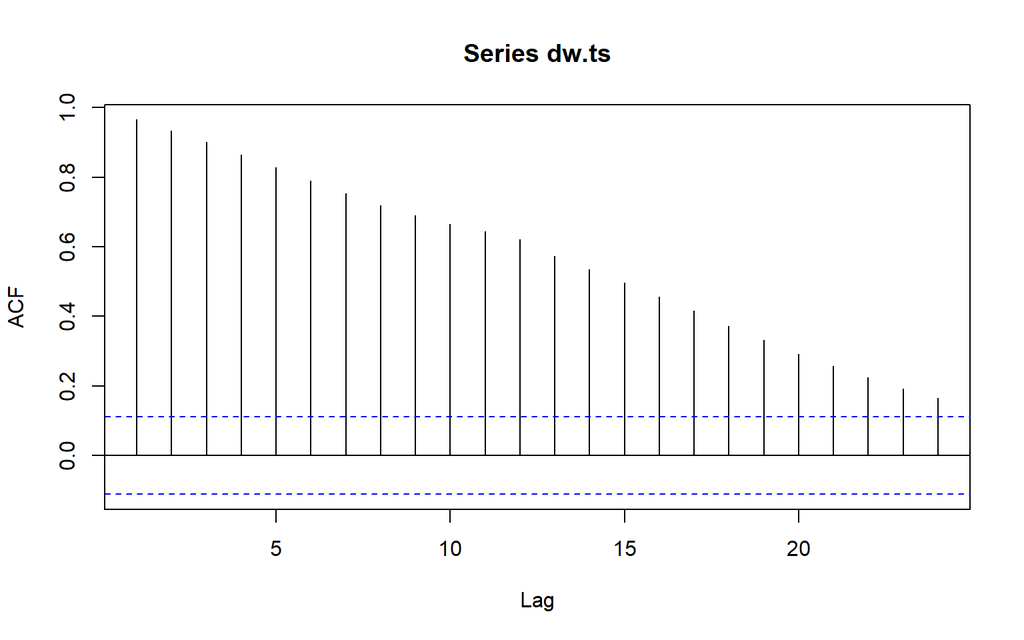

```r
acf(dw.ts)
```

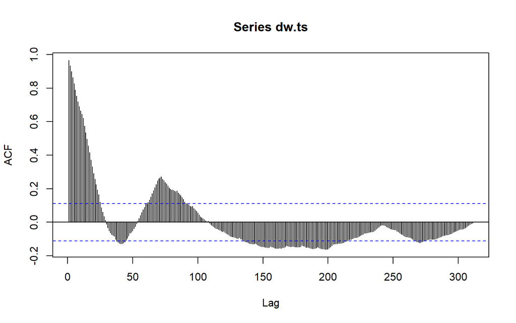

```r
acf(dw.ts, lag.max = length(dw.ts) - 1)
```

Berdasarkan plot ACF, terlihat bahwa plot ACF data menurun secara perlahan (*tails of slowly*). Hal ini juga menjadi indikasi bahwa data tidak stasioner dalam rataan

### Uji ADF

```r
tseries::adf.test(dw.ts)
```

```
##
##  Augmented Dickey-Fuller Test
##
## data:  dw.ts
## Dickey-Fuller = -2.5497, Lag order = 6, p-value = 0.3447
## alternative hypothesis: stationary
```

### Plot Box-Cox

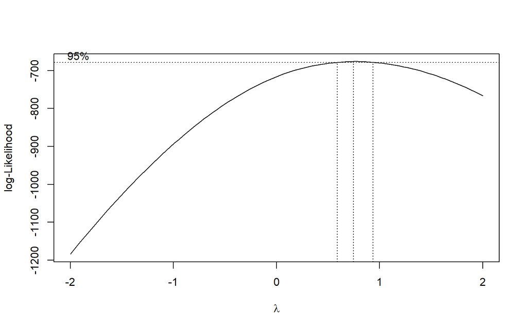

```r
index <- seq(1:312)
bc = boxcox(dw.ts~index, lambda = seq(-2,2,by=1))
```

```r
#Nilai Rounded Lambda
lambdaw <- bc$x[which.max(bc$y)]
lambdaw
```

```
## [1] 0.7474747
```

```r
#SK
bc$x[bc$y > max(bc$y) - 1/2 * qchisq(.95,1)]
```

```
## [1] 0.6262626 0.6666667 0.7070707 0.7474747 0.7878788 0.8282828 0.8686869
## [8] 0.9090909
```

Plot Boxcox menunjukkan nilai *rounded value* ($\lambda$) optimum sebesar **0.7474** dan pada selang kepercayaan 95% nilai memiliki batas bawah **0.6263** dan batas atas **0.9091**. Selang tersebut tidak memuat nilai satu sehingga data tidak stasioner dalam ragam.

## Penanganan Ketidakstasioneran Data

### Transformasi Box-Cox

```r
dw.ts <- (dw.ts^lambdaw - 1) / lambdaw
```

### Plot Box-Cox

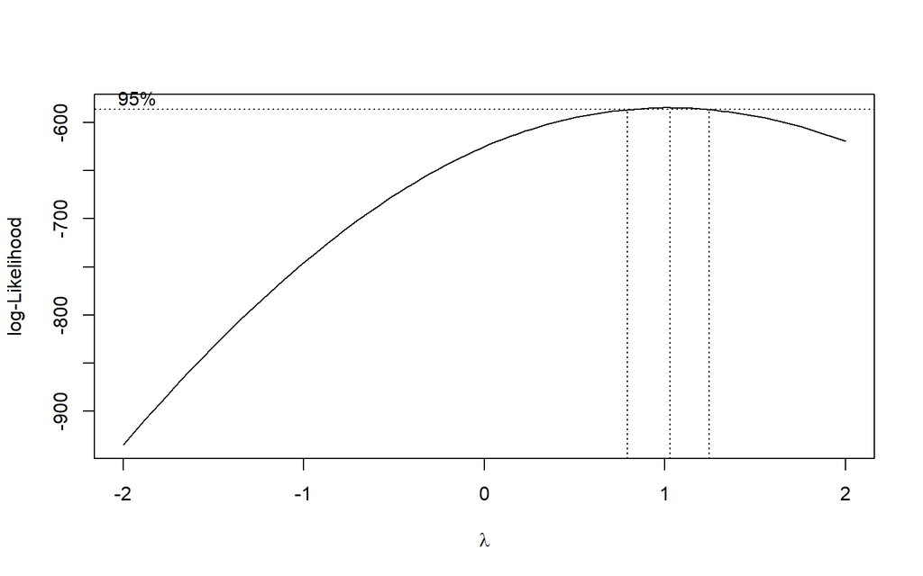

```r
index <- seq_along(dw.ts)
bc = boxcox(dw.ts~index, lambda = seq(-2,2,by=1))
```

```r
#Nilai Rounded Lambda
lambdaw <- bc$x[which.max(bc$y)]
lambdaw
```

```
## [1] 1.030303
```

```r
#SK
bc$x[bc$y > max(bc$y) - 1/2 * qchisq(.95,1)]
```

```
##  [1] 0.8282828 0.8686869 0.9090909 0.9494949 0.9898990 1.0303030 1.0707071
##  [8] 1.1111111 1.1515152 1.1919192 1.2323232
```

### Differencing

[figure not shown]

```r
dw.diff <- diff(dw.ts,differences = 1)
plot.ts(dw.diff, lty=1, xlab="Waktu", ylab="Data Difference 1 Nilai Tukar Rupiah", main="Plot Difference Nilai Tukar Rupiah")
```

Berdasarkan plot data deret waktu, terlihat bahwa data sudah stasioner dalam rataan ditandai dengan data bergerak pada nilai tengah tertentu

### Plot ACF

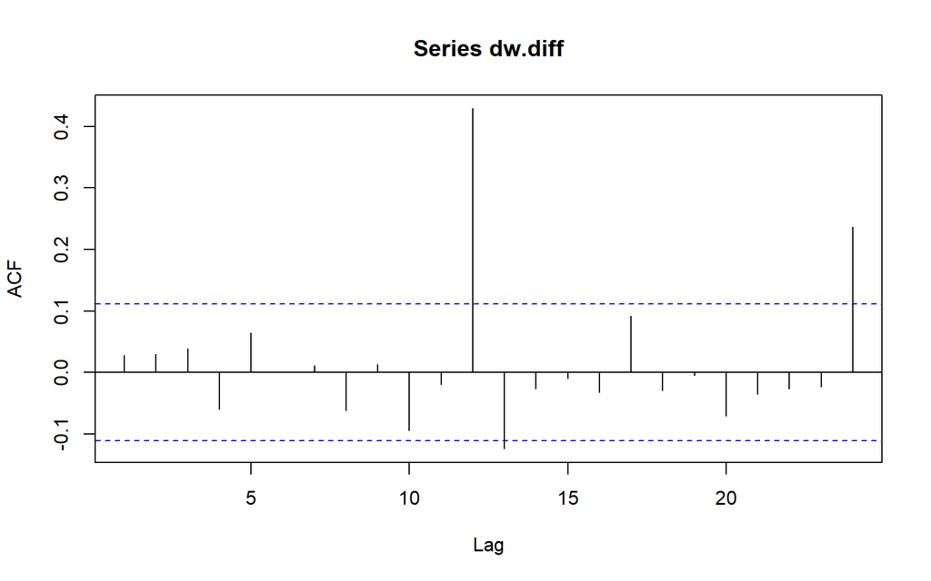

```r
acf(dw.diff)
```

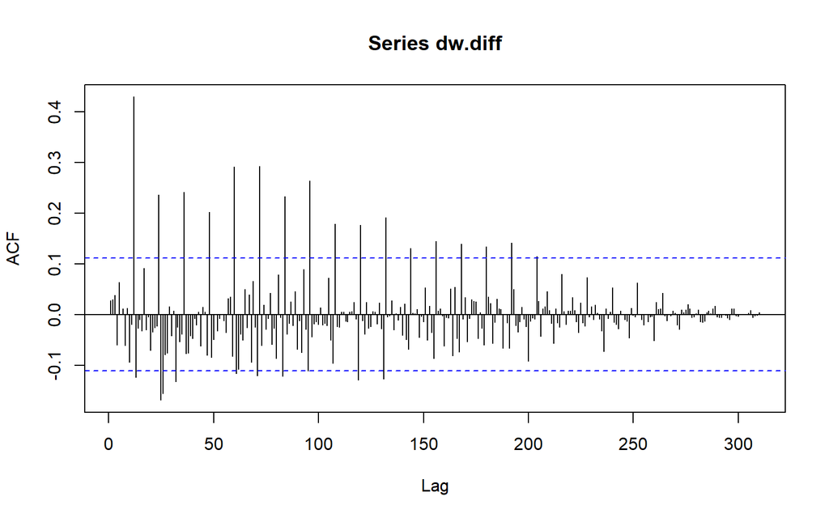

```r
acf(dw.diff, lag.max = length(dw.ts) - 1)
```

Berdasarkan plot tersebut, terlihat bahwa plot ACF tidak tails off slowly. Hal ini menandakan data sudah stasioner dalam rataan dan ketidakstasioneran data telah berhasil tertangani.

### Uji ADF

```r
tseries::adf.test(dw.diff)
```

```
##
##  Augmented Dickey-Fuller Test
##
## data:  dw.diff
## Dickey-Fuller = -6.1786, Lag order = 6, p-value = 0.01
## alternative hypothesis: stationary
```

Berdasarkan uji ADF tersebut, didapat *p-value* sebesar 0.01 yang lebih kecil dari taraf nyata 5% sehingga tolak $H_0$ atau data stasioner dalam rataan. Hal ini sesuai dengan hasil eksplorasi menggunakan plot time series dan plot ACF, sehingga dalam hal ini ketidakstasioneran data sudah berhasil ditangani dan dapat dilanjutkan ke pemodelan